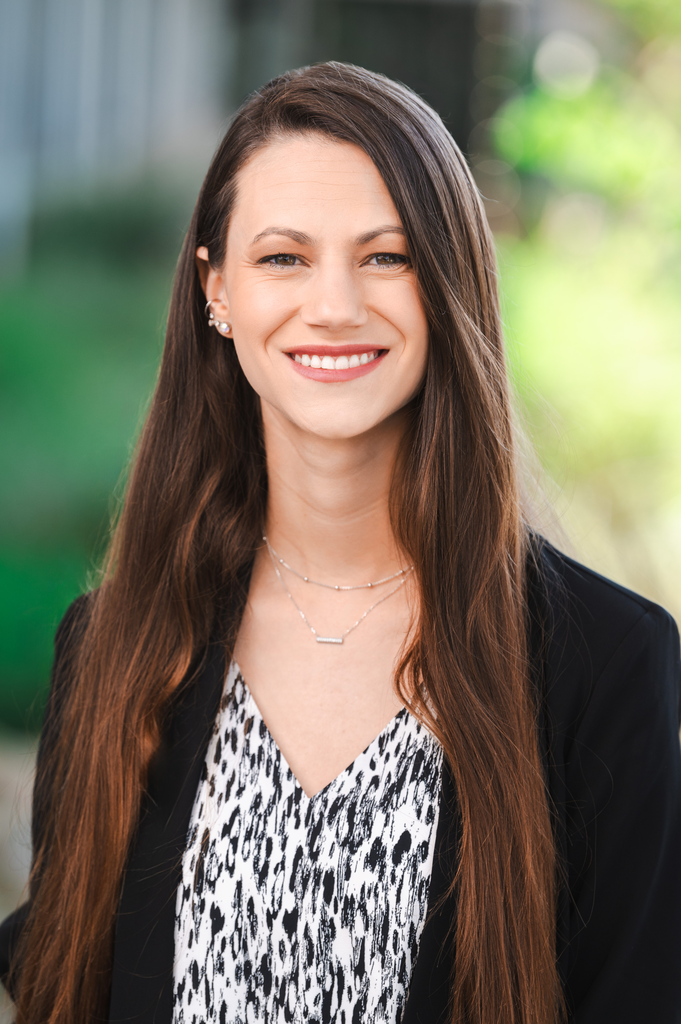

# Allie Caughman

#### Bio

I am a quantitative marine ecologist and PhD Candidate in the [Bren School of Environmental Science and Management](https://bren.ucsb.edu/) at the University of California, Santa Barbara advised by [Steve Gaines](https://gaineslabucsb.com/people/steve-gaines/) and [Darcy Bradley](https://www.scienceforconservation.org/our-team/darcy-bradley). I received my BS in Biology from the Georgia Institute of Technology in 2020 and my MA in Statistics from the University of California, Santa Barbara in 2024.

I work at the intersection of marine animal movement ecology, conservation, and data science and use a broad range of theoretical simulations, data synthesis, and statistical and predictive modeling to understand animal movement processes from individuals to populations to global distributions. I aim to answer a broad range of foundational ecological questions about how, why, and where species are moving, with a particular interest in how these processes are changing due to human influence. The end goal of much of my research is producing actionable conservation solutions.

During my time in the [Gaines](https://gaineslabucsb.com/) and Bradley labs, I am researching in how different movement traits or movement trait combinations effect the conservation of species both now and in the future. I have investigated both climate change and direct human impacts in protected areas and beyond. I am currently supported by the National Science Foundation Graduate Research Fellows Program.

Outside of my research, I put my quantitative skills to use by consulting on a variety of environmental science problems. While my expertise remains in fisheries, ecology, and conservation, I am well versed in a range of methods that can be applied to any environmental issue. From machine learning and statistics, to data management (including spatial data!), I am always looking for opportunities to work with organizations.

I spend most of my free time rock climbing at the Santa Barbara Rock Gym in downtown Santa Barbara. I also enjoy hiking, kayaking, SCUBA Diving and other outdoor activities!

#### Education

B.S. Biology | Georgia Institute of Technology | 2020

M.A. Statistics (Data Science) | University of California, Santa Barbara | 2024

M.S. Environmental Science and Management | University of California, Santa Barbara | 2026

Ph.D. Environmental Science and Management | University of California, Santa Barbara | 2026 (expected)

#### Contact

Primary Email: acaughman@bren.ucsb.edu

Consulting Contact: acaughman.consult@gmail.com